# Taller 2: Analisis Multivariado

2025-11-11

## PCA

## 1) Cargar base y ajustar PCA

```r
# 1) Considerar la base df_pca.csv
df <- read.csv("df_pca.csv")
pca <- prcomp(df, center = TRUE, scale. = TRUE)
```

1. Elegir número de componentes

**Código:**

```r
diagPCA = function(pca){
  print("Summary:")
  print(summary(pca))
}
diagPCA(pca)
```

```
## [1] "Summary:"
## Importance of components:
##                           PC1    PC2    PC3       PC4       PC5      PC6
## Standard deviation     2.1942 1.7901 1.4076 1.933e-07 8.654e-08 6.35e-08
## Proportion of Variance 0.4814 0.3204 0.1981 0.000e+00 0.000e+00 0.00e+00
## Cumulative Proportion  0.4814 0.8019 1.0000 1.000e+00 1.000e+00 1.00e+00
##                              PC7      PC8      PC9      PC10
## Standard deviation     4.995e-08 2.16e-08 7.06e-09 5.323e-09
## Proportion of Variance 0.000e+00 0.00e+00 0.00e+00 0.000e+00
## Cumulative Proportion  1.000e+00 1.00e+00 1.00e+00 1.000e+00
```

## Resumen PCA

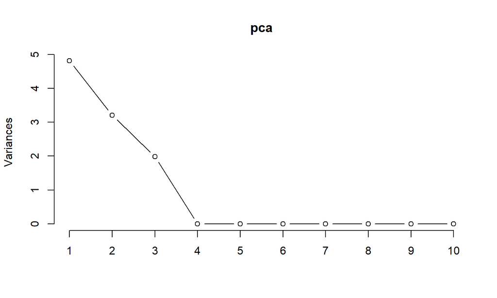

```r
diagPCA = function(pca){
  print(screeplot(pca, type = "lines"))
}
diagPCA(pca)
```

## Conclusión y selección de K

A partir del gráfico de screeplot y del reusmen de la varianza explicada, se seleccionaron 3 componentes principales.

**¿Por qué?:**

1. PC1, PC2 y PC3 tienen 100% en cummulative variance
2. En el screeplot, según el criterio del codo, se ve como para PC4 deja de ganar varianza significativa

## b) Reconstrucción con PCA y con SVD (k = 3)

**Código a cambiar (parciales con ’___’):**

```r
recDataRed_pca=function(df,k){
  n=nrow(___)
  p=ncol(___)
  pca_Aux=prcomp(___,center = ___,scale. = ___)
  z_Aux=pca_Aux$x[,___]
  v_Aux=pca_Aux$rotation[,___]
  s_Aux=diag(pca_Aux$____)
  m_Aux=matrix(pca_Aux$center,nrow = ___,ncol = ___,byrow = T)
  df_Red=z_Aux%*%t(v_Aux)%*%s_Aux+m_Aux
  return(df_Red)
}
recDataRed_svd=function(df,k){
  n=nrow(___)
  p=ncol(___)
  df_sc=scale(___)
  m_sc=attr(df_sc,"scaled:center")
  M_sc=matrix(m_sc,nrow=____,ncol=____,byrow = T)
  s_sc=attr(df_sc,"scaled:scale")
  svd_Aux=svd(as.matrix(____))
  u_Aux=svd_Aux$___[,___]
  d_Aux=diag(svd_Aux$___[___])
  v_Aux=svd_Aux$___[,___]
  df_Red=u_Aux%*%d_Aux%*%t(v_Aux)%*%diag(s_sc)+M_sc
  return(df_Red)
}
```

**Código resuelto y ejecutable:**

```r
recDataRed_pca = function(df, k){
  n = nrow(df); p = ncol(df)
  pca_Aux = prcomp(df, center = TRUE, scale. = TRUE)
  z_Aux = pca_Aux$x[, 1:k]
  v_Aux = pca_Aux$rotation[, 1:k]
  s_Aux = diag(pca_Aux$scale)
  m_Aux = matrix(pca_Aux$center, nrow = n, ncol = p, byrow = TRUE)
  df_Red = z_Aux %*% t(v_Aux) %*% s_Aux + m_Aux
  df_Red
}

recDataRed_svd = function(df, k){
  n = nrow(df); p = ncol(df)
  df_sc = scale(df)
  m_sc  = attr(df_sc, "scaled:center")
  M_sc  = matrix(m_sc, nrow = n, ncol = p, byrow = TRUE)
  s_sc  = attr(df_sc, "scaled:scale")
  svd_Aux = svd(as.matrix(df_sc))
  u_Aux = svd_Aux$u[, 1:k]
  d_Aux = diag(svd_Aux$d[1:k])
  v_Aux = svd_Aux$v[, 1:k]
  df_Red = u_Aux %*% d_Aux %*% t(v_Aux) %*% diag(s_sc) + M_sc
  df_Red
}

k <- 3
Xhat_pca <- recDataRed_pca(df, k)
Xhat_svd <- recDataRed_svd(df, k)
all.equal(Xhat_pca, Xhat_svd)
```

```
## [1] TRUE
```

**Conclusión:**

Ambas reconstrucciones coinciden (all.equal = TRUE). PCA y SVD generan exactamente la misma aproximación de los datos cuando se mantiene el mismo número de componentes k

## c) Scores en PC1–PC2 (color por cos2)

**Código a cambiar:**

```r
scorePlot_PCA=function(pca,ax,col.Ch,tit=""){
  sPl=fviz_pca_ind(____,axes = ____, geom.ind = "point",
                   col.ind = ____, title = ____,
                   gradient.cols = c("#00AFBB", "#E7B800", "#FC4E07"))
  return(sPl)
}
```

**Código resuelto + gráfico:**

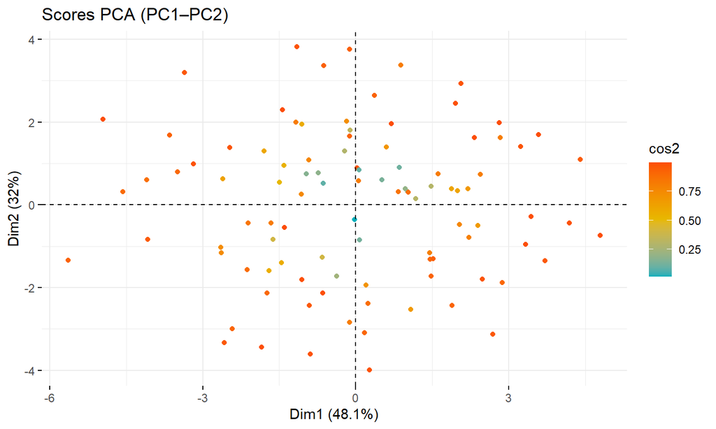

```r
scorePlot_PCA = function(pca, ax, col.Ch, tit = ""){
  sPl = fviz_pca_ind(pca, axes = ax, geom.ind = "point",
                     col.ind = col.Ch, title = tit,
                     gradient.cols = c("#00AFBB", "#E7B800", "#FC4E07"))
  sPl
}
scorePlot_PCA(pca, ax = c(1,2), col.Ch = "cos2", tit = "Scores PCA (PC1–PC2)")
```

**Conclusiones / Observaciones:**

1. Cada punto es una observación proyectada sobre los dos primeros componentes principales (PC1 y PC2), que juntos explican apróximadamente 80% de la varianza total
2. No se observan clusters fuertes
3. El color por cos2 permite ver qué observaciones están mejor representadas por el plano PC1–PC2:
- los puntos más amarillo/rojo = mayor calidad de representación
- los puntos más verdes/azules = quedan mejor explicados por componentes posteriores

## d) Cargas / correlaciones (vars vs PCs)

**Código a cambiar:**

```r
corPlot_PCA=function(pca,ax,col.Ch,tit=""){
  cPl=fviz_pca_var(___,axes = ____,
                   col.var = ____,title=___,
                   gradient.cols = c("#00AFBB", "#E7B800", "#FC4E07"))
  return(cPl)
}
```

**Código resuelto + gráfico:**

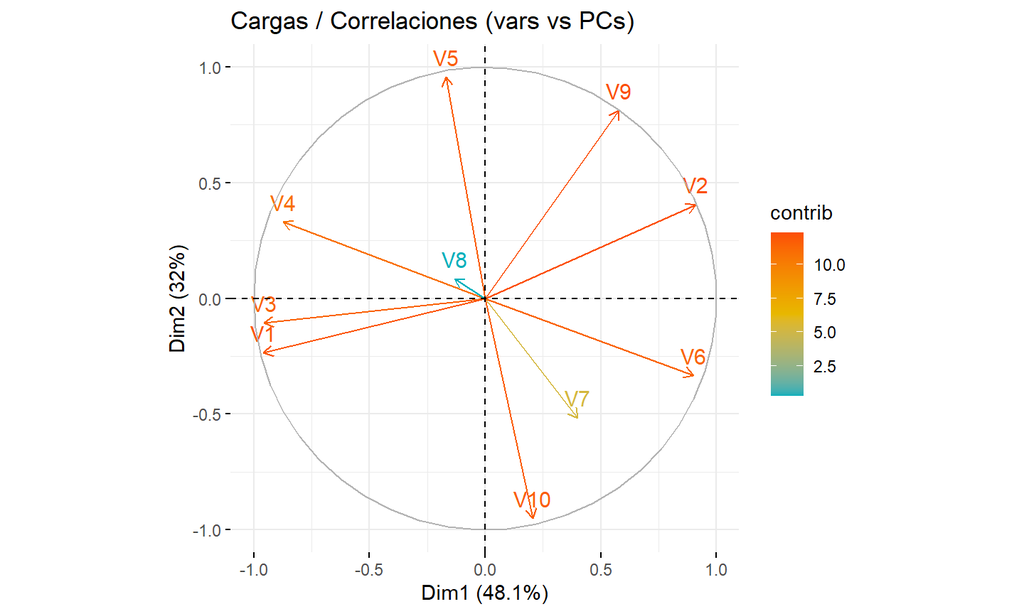

```r
corPlot_PCA = function(pca, ax, col.Ch, tit = ""){
  cPl = fviz_pca_var(pca, axes = ax,
                     col.var = col.Ch, title = tit,
                     gradient.cols = c("#00AFBB", "#E7B800", "#FC4E07"))
  cPl
}
corPlot_PCA(pca, ax = c(1,2), col.Ch = "contrib",
            tit = "Cargas / Correlaciones (vars vs PCs)")
```

**Conclusiones / Observaciones:** El gráfico muestra como cada variable contribuye a la los dos primeros componentes principales

1. Como la gran mayoría están cercanas al circulo, contribuyen bastante
2. V7 contribuye un poco menos que el resto
3. V8 es la que menos contribuye, además se puede ver por qué está coloreada de azul

## e) Biplot (individuos + variables)

**Código a cambiar:**

```r
biPlot_PCA=function(pca,ax,colI.Ch,colV.Ch,tit=""){
  bPl=fviz_pca_biplot(____,axes=___,
                      geom.ind = "point", col.ind = ____,
                      col.var = _____,
                      gradient.cols = c("#00AFBB", "#E7B800", "#FC4E07"),title=____)
  return(bPl)
}
```

**Código resuelto + gráfico:**

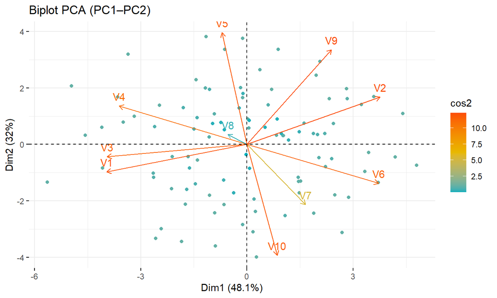

```r
biPlot_PCA = function(pca, ax, colI.Ch, colV.Ch, tit = ""){
  bPl = fviz_pca_biplot(pca, axes = ax,
                        geom.ind = "point", col.ind = colI.Ch,
                        col.var = colV.Ch,
                        gradient.cols = c("#00AFBB", "#E7B800", "#FC4E07"),
                        title = tit)
  bPl
}
biPlot_PCA(pca, ax = c(1,2), colI.Ch = "cos2", colV.Ch = "contrib",
           tit = "Biplot PCA (PC1–PC2)")
```

**Conclusiones / Observaciones:**

El biplot permite interpretar al mismo tiempo la ubicación de las observaciones y el rol de las variables dentro del PCA

1. puntos ubicados hacia la derecha del eje se asocian a mayores valores de V2 y V6
2. puntos ubicados hacia la izquierda del eje se asocian a mayores valores de V1, V3 y V4

## Análisis Factorial (AF)

## 2. Cargar base y diagnosticar número de factores

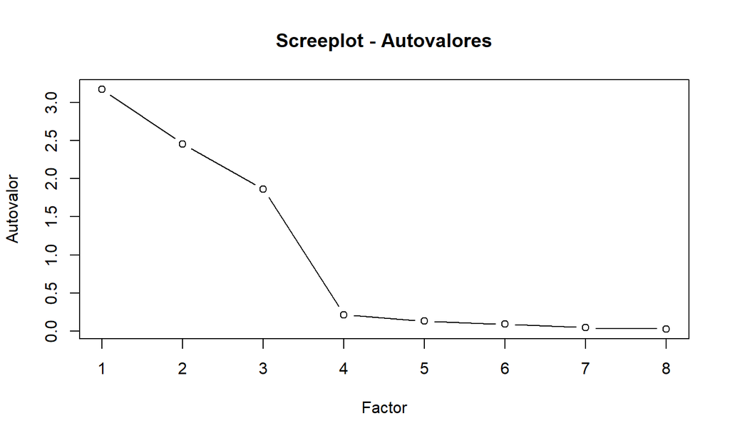

```r
df_af <- read.csv("df_af.csv")
# Matriz de correlaciones y autovalores
eig_vals <- eigen(cor(df_af))$values
plot(eig_vals, type = "b", main = "Screeplot - Autovalores",
     xlab = "Factor", ylab = "Autovalor")
```

Probar con `factanal` y elegir **3 factores** (según ejemplo):

```r
factanal(df_af, factors = 1)
```

```
##
## Call:
## factanal(x = df_af, factors = 1)
##
## Uniquenesses:
##    V1    V2    V3    V4    V5    V6    V7    V8
## 1.000 0.020 0.037 0.999 0.332 0.998 1.000 0.999
##
## Loadings:
##    Factor1
## V1
## V2  0.990
## V3  0.981
## V4
## V5  0.817
## V6
## V7
## V8
##
##                Factor1
## SS loadings      2.616
## Proportion Var   0.327
##
## Test of the hypothesis that 1 factor is sufficient.
## The chi square statistic is 5996.28 on 20 degrees of freedom.
## The p-value is 0
```

```r
factanal(df_af, factors = 2)
```

```
##
## Call:
## factanal(x = df_af, factors = 2)
##
## Uniquenesses:
##    V1    V2    V3    V4    V5    V6    V7    V8
## 0.999 0.020 0.037 0.064 0.117 0.600 0.999 0.026
##
## Loadings:
##    Factor1 Factor2
## V1
## V2  0.988
## V3  0.979
## V4          0.964
## V5  0.845   0.412
## V6          0.628
## V7
## V8          0.985
##
##                Factor1 Factor2
## SS loadings      2.667   2.473
## Proportion Var   0.333   0.309
## Cumulative Var   0.333   0.642
##
## Test of the hypothesis that 2 factors are sufficient.
## The chi square statistic is 2117.88 on 13 degrees of freedom.
## The p-value is 0
```

```r
AF3 <- factanal(df_af, factors = 3, scores = "regression")
AF3
```

```
##
## Call:
## factanal(x = df_af, factors = 3, scores = "regression")
##
## Uniquenesses:
##    V1    V2    V3    V4    V5    V6    V7    V8
## 0.103 0.020 0.037 0.057 0.116 0.265 0.160 0.033
##
## Loadings:
##    Factor1 Factor2 Factor3
## V1                  0.947
## V2  0.989
## V3  0.980
## V4          0.969
## V5  0.837   0.429
## V6          0.624   0.585
## V7                  0.917
## V8          0.982
##
##                Factor1 Factor2 Factor3
## SS loadings      2.651   2.481   2.079
## Proportion Var   0.331   0.310   0.260
## Cumulative Var   0.331   0.641   0.901
##
## Test of the hypothesis that 3 factors are sufficient.
## The chi square statistic is 5.09 on 7 degrees of freedom.
## The p-value is 0.649
```

**Conclusiones / Observaciones:**

Viendo el screeplot, las unicidades, la varianza explicada y el test Chi-square, se concluye que la solución óptima es extraer 3 factores

## b) Cargas factoriales

**Código a cambiar:**

```r
RepFact=function(AnFact,Facts=1:2){
  loadings = as.data.frame(AnFact$____[, Facts])
  LabFacts=paste0("Factor",____)
  GG=ggplot(loadings, aes(x = get(LabFacts[1]), y = get(LabFacts[2]), label = rownames(_____))) +
    geom_point() + geom_text(vjust = -0.5) +
    labs(title = "Cargas Factoriales")+
    xlab(LabFacts[1])+ylab(LabFacts[2])+
    theme_bw()+
    xlim(c(-1.2,1.2))+ylim(c(-1.2,1.2))+
    coord_equal()
  return(GG)
}
```

**Código resuelto + gráfico:**

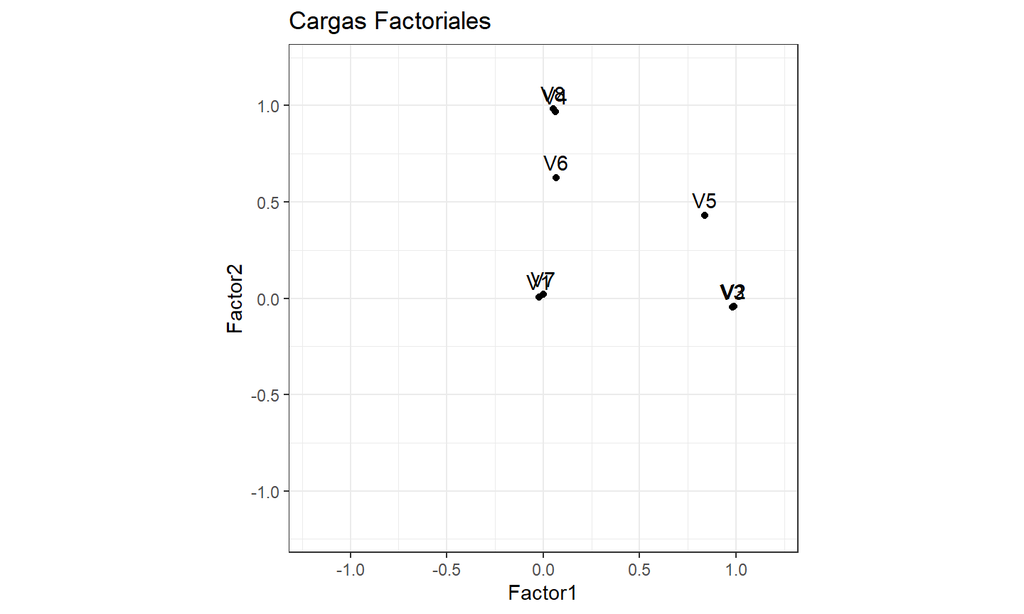

```r
RepFact = function(AnFact, Facts = 1:2){
  loadings = as.data.frame(AnFact$loadings[, Facts])
  LabFacts = paste0("Factor", Facts)
  GG = ggplot(loadings, aes(x = get(LabFacts[1]), y = get(LabFacts[2]),
                            label = rownames(loadings))) +
    geom_point() + geom_text(vjust = -0.5) +
    labs(title = "Cargas Factoriales") +
    xlab(LabFacts[1]) + ylab(LabFacts[2]) +
    theme_bw() +
    xlim(c(-1.2, 1.2)) + ylim(c(-1.2, 1.2)) +
    coord_equal()
  GG
}
RepFact(AF3, Facts = 1:2)
```

**Conclusiones / Observaciones:**

A partir del gráfico de cargas factoriales (factores 1 y 2), se observa:

1. V8 y V4 tienen cargas muy altas en el factor 2 (cerca de 1), por lo cual explican bastante del factor
2. V2, V3 y V5 tienen cargas altas en el factor uno (entre 0,8 y 1), por lo cual determinan al factor
3. V7 y V1 están en el medio, por lo cual no dominan en ninguno de los dos factores

## c) Scores factoriales (observaciones)

**Código a cambiar:**

```r
RepScore=function(AnFact,Facts=1:2,col=NULL){
  scores = as.data.frame(AnFact$_____)
  LabFacts=paste0("Factor",____)
  if(is.null(col)){
    GG=ggplot(scores, aes(x = get(LabFacts[1]), y = get(LabFacts[2]))) +
      geom_point(alpha=0.5)
  }else{
    ColFacts=paste0("Factor",___)
    GG=ggplot(scores, aes(x = get(LabFacts[1]), y = get(LabFacts[2]),color=get(ColFacts))) +
      geom_point(alpha=0.5)+
      labs(color = ____)+
      scale_color_viridis_c()
  }
  GG=GG+
    labs(title = "Scores Factoriales")+
    xlab(LabFacts[1])+ylab(LabFacts[2])+
    theme_bw()+
    coord_equal()
  return(GG)
}
```

**Código resuelto + gráfico:**

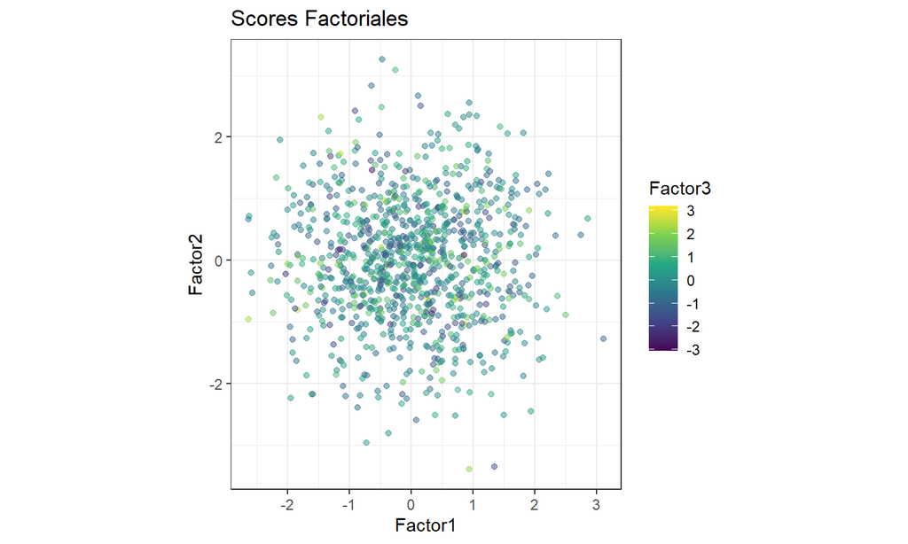

```r
RepScore = function(AnFact, Facts = 1:2, col = NULL){
  scores = as.data.frame(AnFact$scores)
  LabFacts = paste0("Factor", Facts)
  if (is.null(col)){
    GG = ggplot(scores, aes(x = get(LabFacts[1]), y = get(LabFacts[2]))) +
      geom_point(alpha = 0.5)
  } else {
    ColFacts = paste0("Factor", col)
    GG = ggplot(scores, aes(x = get(LabFacts[1]), y = get(LabFacts[2]), color = get(ColFacts))) +
      geom_point(alpha = 0.5) +
      labs(color = ColFacts) +
      scale_color_viridis_c()
  }
  GG = GG +
    labs(title = "Scores Factoriales") +
    xlab(LabFacts[1]) + ylab(LabFacts[2]) +
    theme_bw() + coord_equal()
  GG
}
RepScore(AF3, Facts = 1:2, col = 3)
```

**Conclusiones / Observaciones:**

El gráfico de scores factoriales muestra cómo se distribuyen las observaciones en el espacio definido por los factores 1 y 2, con el factor 3 representado por el color

1. las observaciones se concentran principalmente alrededor del origen
2. no se ve una agrupación relacionada al factor 3

## Análisis de Correspondencias (CA)

## 3. Cargar tabla y preparar rótulos

```r
Tab <- read.csv("Tab_ca.csv")
nR <- nrow(Tab); nC <- ncol(Tab)
colnames(Tab) <- paste0("A", 1:nC)
rownames(Tab) <- paste0("B", 1:nR)
```

## a) Valores esperados bajo independencia

**Código a cambiar:**

```r
EMat=function(Tab){
  nR=nrow(Tab); nC=ncol(Tab)
  sR=rowSums(Tab); sC=colSums(Tab); sT=sum(Tab)
  E=as.matrix(___)%*%t(as.matrix(___))/___
  colnames(E)=paste0("A",1:nC); rownames(E)=paste0("B",1:nR)
  return(E)
}
```

**Código resuelto:**

```r
EMat = function(Tab){
  nR = nrow(Tab); nC = ncol(Tab)
  sR = rowSums(Tab); sC = colSums(Tab); sT = sum(Tab)
  E = as.matrix(sR) %*% t(as.matrix(sC)) / sT
  colnames(E) = paste0("A", 1:nC); rownames(E) = paste0("B", 1:nR)
  E
}
E <- EMat(Tab)
print(E)
```

```
##           A1        A2       A3        A4        A5       A6        A7       A8
## B1  13.68129  7.209302 13.10782 10.322410  9.912791 10.97780 10.322410 10.73203
## B2  18.44767  9.720930 17.67442 13.918605 13.366279 14.80233 13.918605 14.47093
## B3  17.12368  9.023256 16.40592 12.919662 12.406977 13.73996 12.919662 13.43235
## B4  19.94820 10.511628 19.11205 15.050740 14.453488 16.00634 15.050740 15.64799
## B5  20.38953 10.744186 19.53488 15.383721 14.773256 16.36047 15.383721 15.99419
## B6  16.59408  8.744186 15.89852 12.520085 12.023256 13.31501 12.520085 13.01691
## B7  13.15169  6.930233 12.60042  9.922833  9.529070 10.55285  9.922833 10.31660
## B8  16.50581  8.697674 15.81395 12.453488 11.959302 13.24419 12.453488 12.94767
## B9  17.38848  9.162791 16.65962 13.119450 12.598837 13.95243 13.119450 13.64006
## B10 13.76956  7.255814 13.19239 10.389006  9.976744 11.04863 10.389006 10.80127
##            A9       A10      A11       A12      A13       A14       A15
## B1  10.158562  7.209302 10.24049 10.322410 13.84514  7.291226  9.667019
## B2  13.697674  9.720930 13.80814 13.918605 18.66860  9.831395 13.034884
## B3  12.714588  9.023256 12.81712 12.919662 17.32875  9.125793 12.099366
## B4  14.811839 10.511628 14.93129 15.050740 20.18710 10.631078 14.095137
## B5  15.139535 10.744186 15.26163 15.383721 20.63372 10.866279 14.406977
## B6  12.321353  8.744186 12.42072 12.520085 16.79281  8.843552 11.725159
## B7   9.765328  6.930233  9.84408  9.922833 13.30920  7.008985  9.292812
## B8  12.255814  8.697674 12.35465 12.453488 16.70349  8.796512 11.662791
## B9  12.911205  9.162791 13.01533 13.119450 17.59672  9.266913 12.286469
## B10 10.224101  7.255814 10.30655 10.389006 13.93446  7.338266  9.729387
```

## b) Matriz de desviaciones estandarizadas

**Código a cambiar:**

```r
CMat=function(Tab,E){
  C=(___-___)/sqrt(___)
  return(C)
}
```

**Código resuelto:**

```r
CMat = function(Tab, E){
  (Tab - E) / sqrt(E)
}
C <- CMat(Tab, E)
print(C)
```

```
##             A1          A2         A3          A4          A5         A6
## B1   0.3565216 -2.31257692  0.2464257  0.83340000  0.98054630  0.3085160
## B2   1.5255437  0.08950739  1.7424869 -1.05034894 -0.64723307 -0.9882898
## B3  -0.9965206  1.65677557 -1.5815437  0.02235100  0.16835993  0.3399323
## B4   1.1310818  1.07593941  1.3468227 -0.78636878 -1.17142364 -0.2515358
## B5   1.0210361  0.07804363  1.2364996 -0.09783287  0.05899267 -1.3252709
## B6  -0.6368055  2.11555407 -0.4761424 -0.42959985 -0.58349851  0.1877211
## B7  -0.3175743 -2.25267127 -0.4508605  0.34195205  1.12439947  0.1376462
## B8  -0.3706405  0.78066582 -1.2105470  0.72160603 -0.56656342  0.4824651
## B9  -1.5320277  0.27657961 -0.4066081 -0.03297839  0.67648220  0.2804514
## B10 -0.4768748 -2.32241996 -0.8789296  0.81006303  0.32395882  1.1887596
##              A7          A8          A9        A10        A11         A12
## B1  -0.10035018 -0.22345378  0.89150134 -2.3125769  0.5498350  1.45590012
## B2  -0.51426580 -1.17530252 -0.99909147  0.7309770 -0.4865913 -1.05034894
## B3  -0.25586009  0.42773429  0.36048840  1.9896791 -0.5075624 -0.25586009
## B4  -0.01307890 -0.66940244 -0.21094323  0.1506315 -1.0173875 -1.04413208
## B5  -0.60774964 -0.49863712 -0.03586134  0.6882029 -0.3229467 -0.86270803
## B6   0.70086317  0.27248199 -0.66132052  1.1010319 -0.4031204 -0.14698409
## B7   0.65940704  0.83544491  0.07509628 -2.2526713  1.3245842  0.02449706
## B8  -0.69524599  0.57036172 -0.07307236  0.7806658  0.1836028  0.43823563
## B9  -0.03297839  0.09745807  0.58131618  0.6069386  0.2729381  0.51919080
## B10  1.12031389  0.66901340  0.24265673 -2.3224200  0.8389799  1.43056475
##            A13        A14         A15
## B1   0.3103714 -2.3298878  0.10709597
## B2   1.4653572  1.6484119 -0.56361951
## B3  -1.0398702  0.9514430 -0.02856639
## B4   1.0711974  0.4198460 -0.29169834
## B5   0.9612198  0.6472875 -1.16105911
## B6  -0.6815221  0.3888775  0.08026438
## B7   0.4634653 -2.2697267  1.54414467
## B8  -1.6402017  1.4172766  0.09874118
## B9  -1.3341907  0.5693151  0.20356311
## B10  0.2854462 -2.3397731  0.40735270
```

## c) Selección de ejes por varianza explicada

**Código a cambiar:**

```r
pVarEx=function(C){
  svd_Aux=svd(C)
  df_pVE=data.frame("Autovalores"=svd_Aux$___^2)
  df_pVE$Porcentaje_Acumulado=cumsum(df_pVE$Autovalores)*100/sum(df_pVE$Autovalores)
  return(df_pVE)
}
```

**Código resuelto + gráfico:**

```r
pVarEx = function(C){
  svd_Aux = svd(C)
  df_pVE = data.frame(Autovalores = svd_Aux$d^2)
  df_pVE$Porcentaje_Acumulado = cumsum(df_pVE$Autovalores) * 100 / sum(df_pVE$Autovalores)
  df_pVE
}
pVar <- pVarEx(C)
print(pVar)
```

```
##     Autovalores Porcentaje_Acumulado
## 1  8.430156e+01             59.05787
## 2  4.024077e+01             87.24873
## 3  6.767153e+00             91.98949
## 4  4.089121e+00             94.85414
## 5  3.091782e+00             97.02010
## 6  1.844881e+00             98.31254
## 7  1.199085e+00             99.15257
## 8  8.128067e-01             99.72198
## 9  3.968498e-01            100.00000
## 10 6.199007e-31            100.00000
```

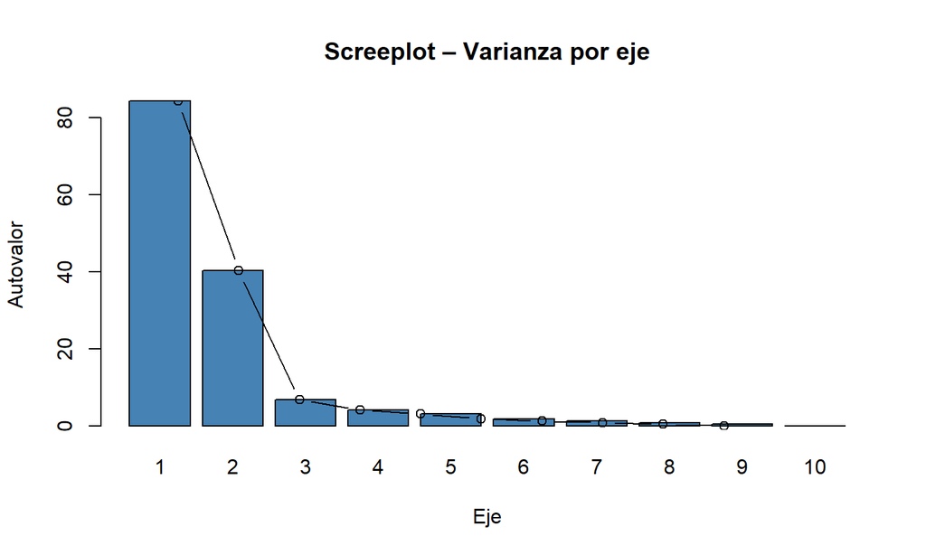

```r
barplot(pVar$Autovalores, names.arg = seq_len(nrow(pVar)),
        main = "Screeplot – Varianza por eje", xlab = "Eje", ylab = "Autovalor", col = "steelblue")
lines(seq_len(nrow(pVar)), pVar$Autovalores, type = "b")
```

**Conclusiones / Observaciones:**

En cuanto a los ejes:

1. El eje 1 explica el 59% de la variabilidad
2. El eje 2 acumula el 87% de la variabilidad
3. Los dos primeros ejes concentran casi toda la variabilidad del análisis
4. El eje 3 ya aporta solo un 4% adicional

En cuanto al screeplot:

1. Muestra un codo entre el segundo y tercer eje, validando la elección de dos ejes

## d) Coordenadas de filas y columnas + gráfico conjunto

**Código a cambiar:**

```r
rScore=function(C,nRs,k){
  C=as.matrix(C)
  CCt=___%*%t(___)
  eig_Aux=eigen(___)
  A_Aux=diag(1/sqrt(nRs))
  rSc=A_Aux%*%eig_Aux$____[,1:k]%*%diag(sqrt(eig_Aux$____[1:k]))
  rSc=data.frame(rSc)
  names(rSc)=paste0("Eje",1:k)
  rSc$Lab=rownames(C)
  return(rSc)
}

cScore=function(C,nCs,k){
  C=as.matrix(C)
  CtC=t(___)%*%____
  eig_Aux=eigen(____)
  B_Aux=diag(1/sqrt(nCs))
  cSc=B_Aux%*%eig_Aux$____[,1:k]%*%diag(sqrt(eig_Aux$____[1:k]))
  cSc=data.frame(cSc)
  names(cSc)=paste0("Eje",___)
  cSc$Lab=colnames(C)
  return(cSc)
}

RepGraf=function(rS,cS,ejs){
  EjLabs=paste0("Eje",____)
  GG=rS %>%
    ggplot(aes(x=get(EjLabs[1]),y=get(EjLabs[2])))+
    geom_text(aes(label=____),color="blue")+
    geom_text(data=cS,aes(label=___),color="red")+
    theme_bw()+
    xlab(EjLabs[1])+ylab(EjLabs[2])
  return(GG)
}
```

**Código resuelto + gráfico:**

```r
rScore = function(C, nRs, k){
  C = as.matrix(C)
  CCt = C %*% t(C)
  eig_Aux = eigen(CCt)
  A_Aux = diag(1 / sqrt(nRs), nRs, nRs)
  rSc = A_Aux %*% eig_Aux$vectors[, 1:k] %*% diag(sqrt(eig_Aux$values[1:k]))
  rSc = data.frame(rSc); names(rSc) = paste0("Eje", 1:k); rSc$Lab = rownames(C)
  rSc
}

cScore = function(C, nCs, k){
  C = as.matrix(C)
  CtC = t(C) %*% C
  eig_Aux = eigen(CtC)
  B_Aux = diag(1 / sqrt(nCs), nCs, nCs)
  cSc = B_Aux %*% eig_Aux$vectors[, 1:k] %*% diag(sqrt(eig_Aux$values[1:k]))
  cSc = data.frame(cSc); names(cSc) = paste0("Eje", 1:k); cSc$Lab = colnames(C)
  cSc
}

RepGraf = function(rS, cS, ejs){
  EjLabs = paste0("Eje", ejs)
  ggplot(rS, aes(x = get(EjLabs[1]), y = get(EjLabs[2]))) +
    geom_text(aes(label = Lab), color = "blue") +
    geom_text(data = cS, aes(label = Lab), color = "red") +
    theme_bw() + xlab(EjLabs[1]) + ylab(EjLabs[2])
}

k <- 2
rS <- rScore(C, nrow(Tab), k)
print(rS)
```

```
##           Eje1        Eje2 Lab
## 1   1.36541344  0.30993953  B1
## 2  -0.82411601  0.99188434  B2
## 3  -0.67589507 -0.86616879  B3
## 4  -0.62488735  0.67436267  B4
## 5  -0.51279376  0.68317232  B5
## 6  -0.61609027 -0.48723977  B6
## 7   1.40609272  0.09613844  B7
## 8  -0.38014022 -0.75721042  B8
## 9  -0.05886046 -0.66174427  B9
## 10  1.50722411 -0.12051281 B10
```

```r
cS <- cScore(C, ncol(Tab), k)
print(cS)
```

```
##           Eje1        Eje2 Lab
## 1  -0.16621963  0.71806214  A1
## 2  -1.18699151 -0.38945323  A2
## 3  -0.23899297  0.82477497  A3
## 4   0.37563575 -0.22911235  A4
## 5   0.45037746 -0.11569345  A5
## 6   0.31235252 -0.38955000  A6
## 7   0.28721315 -0.07831261  A7
## 8   0.25264448 -0.38961747  A8
## 9   0.25073250 -0.15739249  A9
## 10 -1.17656330 -0.33584874 A10
## 11  0.49672231 -0.11279060 A11
## 12  0.55182572 -0.31358335 A12
## 13  0.08541872  0.81044068 A13
## 14 -1.18335651 -0.09801378 A14
## 15  0.36406099 -0.21112027 A15
```

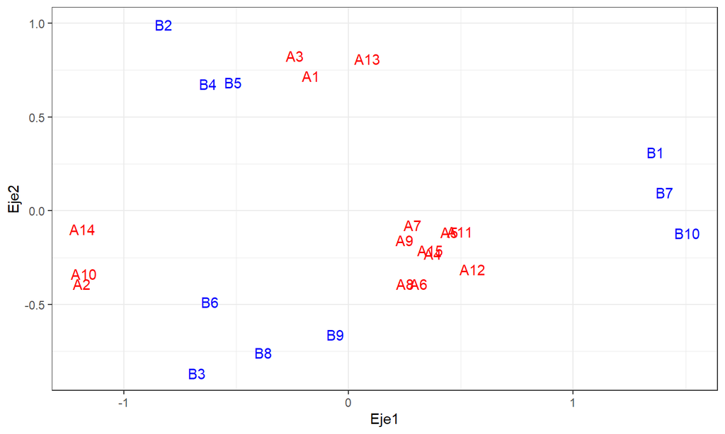

```r
RepGraf(rS, cS, ejs = 1:2)
```

**Conclusiones / Observaciones:**

En cuanto al gráfico:

1. El eje 1 captura la diferencia entre las filas B1, B7 y B10 que están al borde derecho vs el resto de las filas que están a la izquierda
2. También captura la diferencia entre las columnas, hay un grupo agrupado en el centro, y A2, A10 y A14 están sobre el borde izquierdo
3. El eje 2 distingue otros dos grupos:
- Zona superior: B2, B4, B5 y algunas columnas como A1, A3, A13, que comparten coordenadas positivas
- Zona inferior: B3, B6, B8, B9 y columnas como A2, A6, A8, A9, A10, que tienen coordenadas negativas.

Es decir, filas y columnas que aparecen cerca en el gráfico tienden a asociarse en la tabla original

## MDS

## 4. Cargar base y definir funciones

```r
df_mds <- read.csv("df_mds.csv", row.names = 1)

cSoloPos = function(eig) eig[eig > 0] / sum(eig[eig > 0])
cAbs     = function(eig) abs(eig) / sum(abs(eig))
cSq      = function(eig) eig^2 / sum(eig^2)

mds_Mink = function(df, k, p = 1){
  dMat = dist(df, method = "minkowski", p = p)  # Euclídea si p=2; Manhattan si p=1
  mds_Aux = cmdscale(dMat, k, eig = TRUE)
  print("Autovalores:"); print(mds_Aux$eig[1:k])
  print("Criterio Sólo Positivos:"); print(cSoloPos(mds_Aux$eig)[1:k])
  print("Criterio Módulo:"); print(cAbs(mds_Aux$eig)[1:k])
  print("Criterio Cuadrados:"); print(cSq(mds_Aux$eig)[1:k])
  df_mds_out = data.frame(mds_Aux$points)
  names(df_mds_out) = paste0("Dim", 1:k)
  df_mds_out = cbind.data.frame(df_mds_out, df)
  df_mds_out
}

repGrafMDS = function(df_mds, dims, col.Ch = NULL){
  DimLabs = paste0("Dim", dims)
  GG = df_mds %>%
    ggplot(aes(x = get(DimLabs[1]), y = get(DimLabs[2]))) +
    theme_bw() + xlab(DimLabs[1]) + ylab(DimLabs[2])
  if (is.null(col.Ch)){
    GG + geom_text(aes(label = rownames(df_mds)), alpha = 0.5)
  } else {
    GG + geom_text(aes(label = rownames(df_mds), color = get(col.Ch)), alpha = 0.5) +
      scale_color_viridis_c() + labs(colour = col.Ch)
  }
}
```

## a–b) MDS Euclídeo (k = 2) y gráfico

```r
mds_euc <- mds_Mink(df_mds, k = 2, p = 2)
```

```
## [1] "Autovalores:"
## [1] 9814.991 8959.132
## [1] "Criterio Sólo Positivos:"
## [1] 0.3374274 0.3080040
## [1] "Criterio Módulo:"
## [1] 0.3374274 0.3080040
## [1] "Criterio Cuadrados:"
## [1] 0.4975953 0.4145991
```

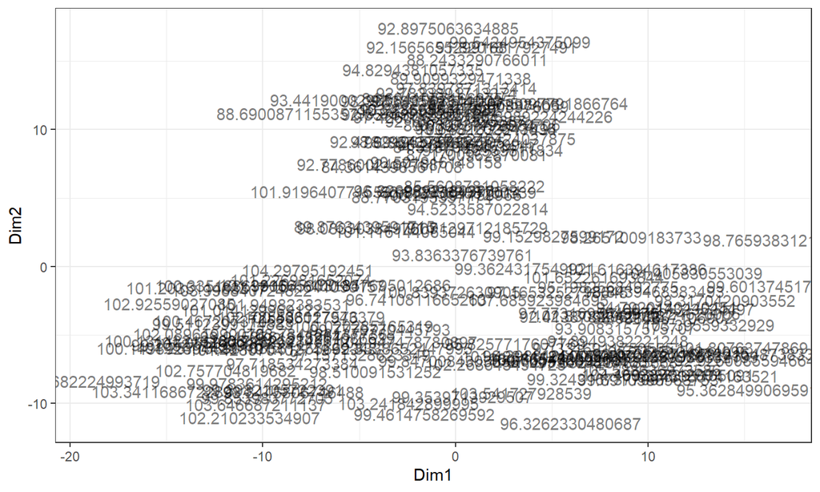

```r
repGrafMDS(mds_euc, dims = 1:2)                 # sin color
```

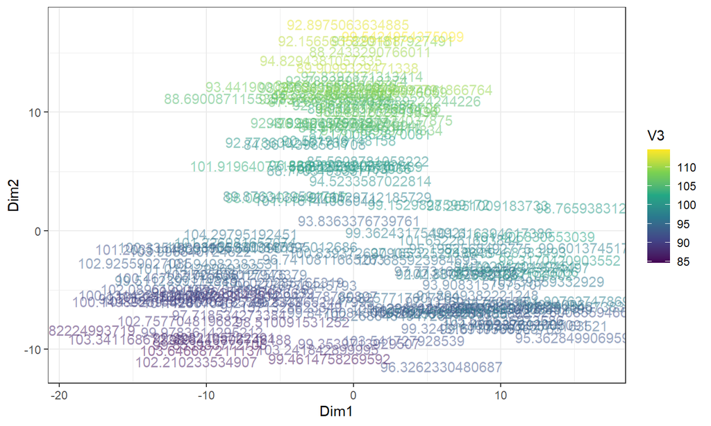

```r
repGrafMDS(mds_euc, dims = 1:2, col.Ch = "V3")  # ejemplo: coloreo por V3 si es numérica
```

**Conclusiones / Observaciones:**

1. Los dos primeros ejes del MDS explican una proporción importante de la variabilidad de las distancias según los criterios analizados (sólo positivos, módulo y cuadrados)
2. Al colorear por V3, se observa un gradiente vertical: valores altos de V3 se ubican hacia la parte superior del gráfico mientras que valores bajos de V3 se ubican hacia la parte inferior
3. Esto indica que V3 influye fuertemente en la primera o segunda dimensión del MDS
4. La dispersión horizontal en Dim1 significa que hay más dimensiones de variación relevantes fuera del gradiente principal

## c) MDS Manhattan (k = 2) y comparación

```r
mds_manh <- mds_Mink(df_mds, k = 2, p = 1)
```

```
## [1] "Autovalores:"
## [1] 70768.57 47975.43
## [1] "Criterio Sólo Positivos:"
## [1] 0.3043087 0.2062969
## [1] "Criterio Módulo:"
## [1] 0.2433543 0.1649747
## [1] "Criterio Cuadrados:"
## [1] 0.6124515 0.2814677
```

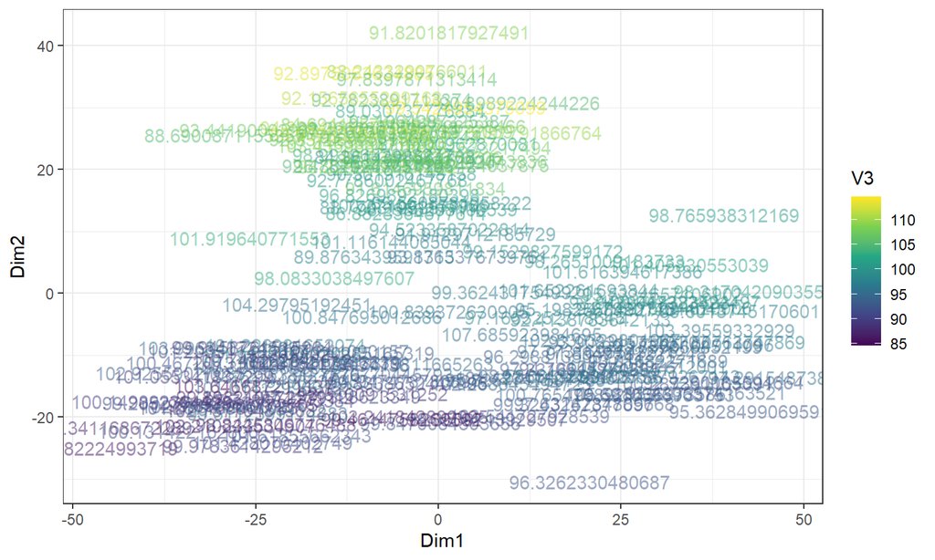

```r
repGrafMDS(mds_manh, dims = 1:2, col.Ch = "V3")
```

**Conclusiones / Diferencias:**

A partir de la ejecución del mismo procedimiento de MDS pero reemplazando la distancia Euclídea por la distancia Manhattan (p = 1), se puede ver:

1. Los autovalores de Manhattan son mucho más altos, lo cual es esperable porque Manhattan acumula distancias absolutas en vez de cuadráticas
2. La proporción explicada por los primeros componentes es menor que en euclídea, por lo cual se pierde algo de información al reducir a 2 dimensiones
3. El gráfico de MDS Manhattan muestra una estructura similar al de euclídea, con un gradiente vertical asociado a V3

## Muchas Gracias

**Muchas Gracias**